# Compare two consensus partitioning results

2024-02-27

### Top 1000 genes under the two top-value methods

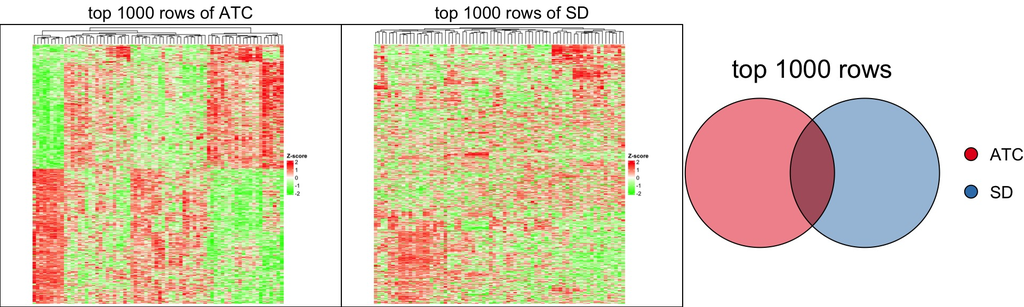

Figure 1. Top 1000 genes with the highest ATC and SD values.

### Compare classifications

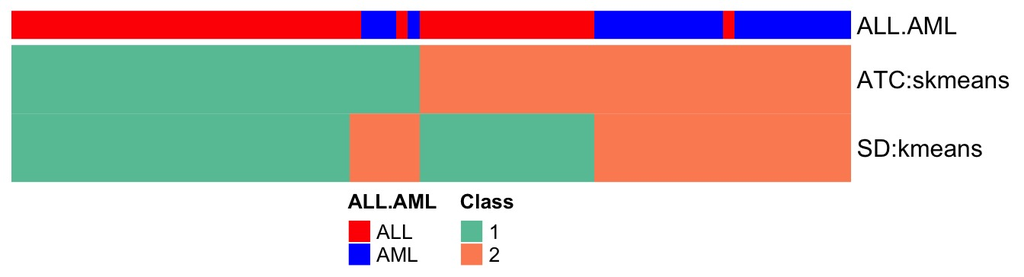

Figure 2. Conseusus partitions from ATC:skmeans and SD:kmeans methods.

### Dimension reduction by UMAP

UMAP plots with 2-group classification for ATC:skmeans and 2-group classification for SD:kmeans:

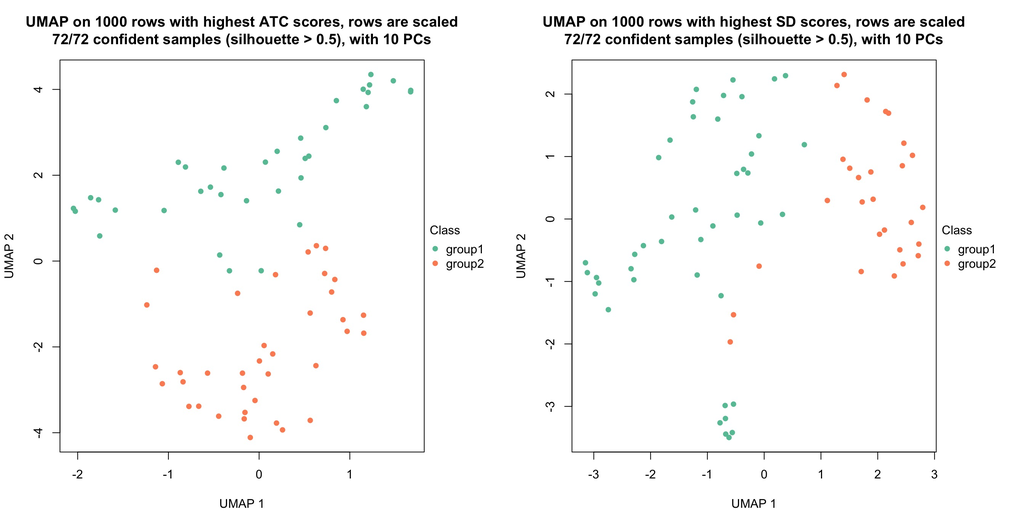

Figure 3. UMAP plots for visualizing the two classifications. Classification on the left plot is from ATC:skmeans and on the right is from SD:kmeans.

### Signature genes (FDR < 0.05)

Signature genes from two classifications:

#### ATC:skmeans (2 groups)

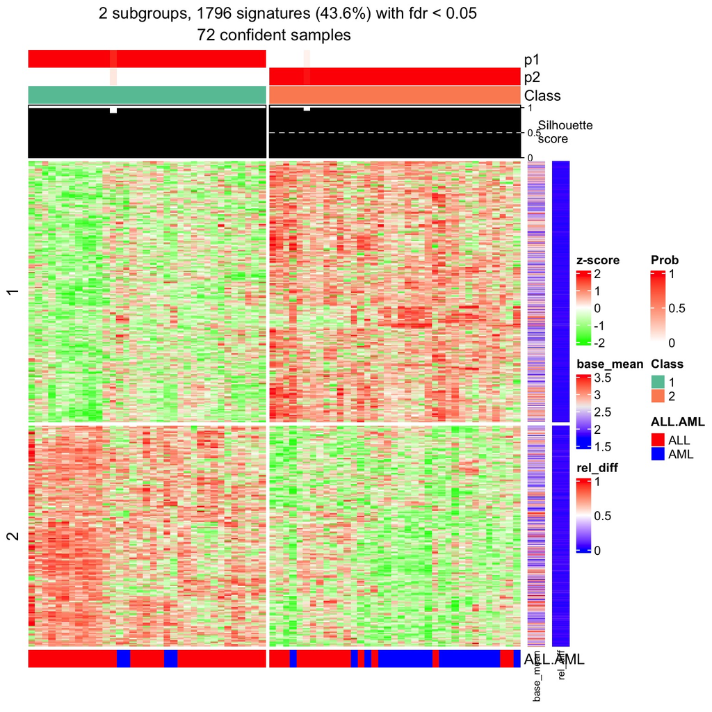

Figure 4A. Signature genes from ATC:skmeans (2-group classification).

#### SD:kmeans (2 groups)

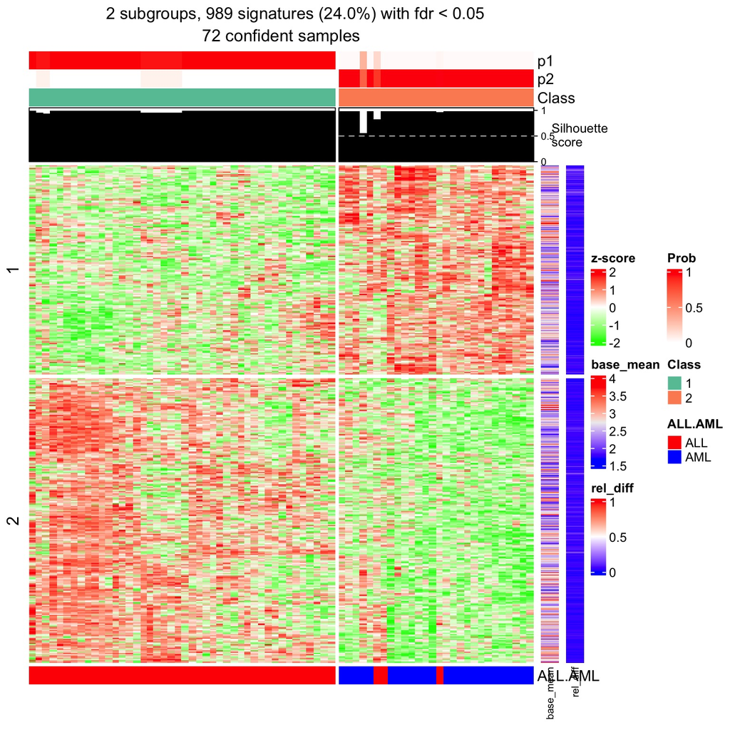

Figure 4B. Signature genes from SD:kmeans (2-group classification).

Overlap of the two signature lists:

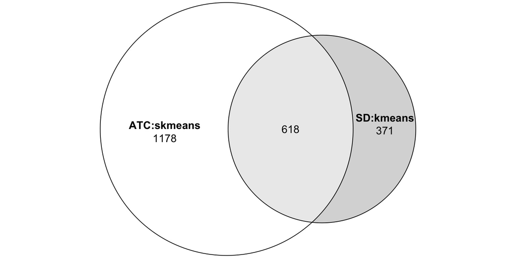

Figure 5. Overlap of signatures in ATC:skmeans and SD:kmeans.

The signature genes are put into three groups, termed as:

- A: 1178 genes specific in ATC:skmeans.
- B: 618 genes common in ATC:skmeans and SD:kmeans.
- C: 371 genes specific in SD:kmeans.

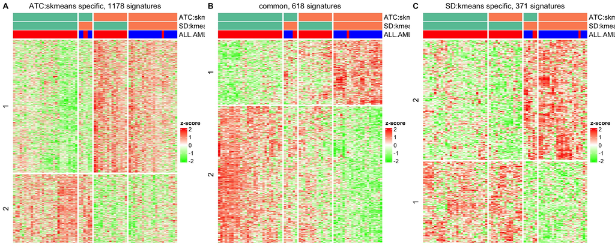

Figure 6. Heatmaps of ATC:skmeans specific signatures, SD:kmeans specific signatures and common signatures in the two classifcations.